# Power Law

Bohao Tang

2018/10/30

## Data

The data here are from `Table 2` in Stoffel and `Figure 2` in Peto_NEJM. (`Figure 3` in Peto_BJC do not have data points with it and `Table 3` in Fuchs do not have age-specific incidences)

Here we show the data, where `Ages`, `Gender`, `Expose` are as the name and `Type` is type of cancer, `CR` is the cumulative risk (in %). If the age-specific instances are in constant ratio between different expose than cumulative risk should remain the same ratio.

```r
library(tidyverse)

Peto_NEJM = read_csv("Peto_NEJM.csv")
Stoffel = read_csv("Stoffel.csv")

Peto_NEJM = Peto_NEJM %>% gather(Ages, CR, -c(Gender, Expose))
Stoffel = Stoffel %>% gather(Ages, CR, -c(Gender, Expose, Type))

Peto_NEJM
```

```
## # A tibble: 20 x 4
##    Expose Gender Ages     CR
##    <chr>  <chr>  <chr> <int>
##  1 N      M      40        2
##  2 S      M      40        4
##  3 N      F      40        1
##  4 S      F      40        1
##  5 N      M      50        5
##  6 S      M      50        9
##  7 N      F      50        3
##  8 S      F      50        5
##  9 N      M      60        8
## 10 S      M      60       23
## 11 N      F      60        5
## 12 S      F      60       15
## 13 N      M      70       19
## 14 S      M      70       45
## 15 N      F      70       13
## 16 S      F      70       32
## 17 N      M      80       39
## 18 S      M      80       74
## 19 N      F      80       30
## 20 S      F      80       62
```

```r
Stoffel
```

```
## # A tibble: 80 x 5
##    Gender Expose Type        Ages      CR
##    <chr>  <chr>  <chr>       <chr>  <dbl>
##  1 M      POP    Colorectal  30    0.0100
##  2 M      MMR    Colorectal  30    1.85
##  3 M      MLH1   Colorectal  30    2.83
##  4 M      MSH2   Colorectal  30    1.43
##  5 F      POP    Colorectal  30    0.0100
##  6 F      MMR    Colorectal  30    0.910
##  7 F      MLH1   Colorectal  30    1.30
##  8 F      MSH2   Colorectal  30    0.710
##  9 F      POP    Endometrial 30    0.0100
## 10 F      MMR    Endometrial 30    0.580
## # ... with 70 more rows
```

## Plots

Here we do some plots to show how far is the data from constant ratio

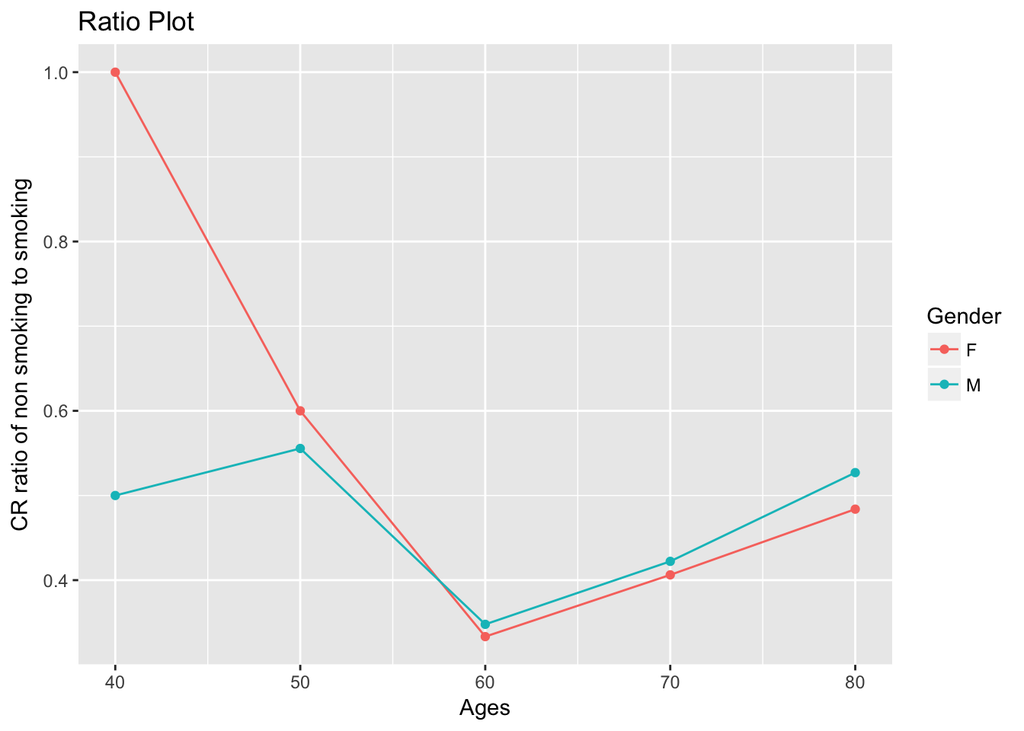

```r
## For Peto data

Peto_NEJM %>% spread(Expose, CR) %>% mutate(ratio=N/S, Ages=as.numeric(Ages)) %>%
              ggplot(aes(x=Ages, y=ratio, color=Gender)) +
              geom_line() + geom_point() +
              xlab("Ages") + ylab("CR ratio of non smoking to smoking") +
              ggtitle("Ratio Plot")
```

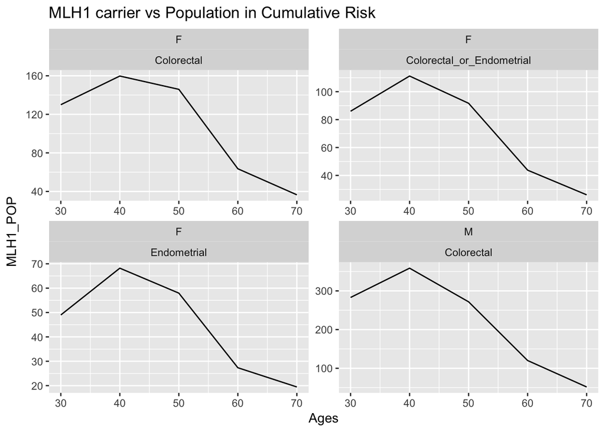

```r
## For Stoffel data

st = Stoffel %>% spread(Expose, CR) %>% mutate(Ages=as.numeric(Ages))
st$'MLH1_POP' = st$MLH1 / st$POP
st$'MMR_POP' = st$MMR / st$POP
st$'MSH2_POP' = st$MSH2 / st$POP
st$'MLH1_MMR' = st$MLH1 / st$MMR
st$'MMR_MSH2' = st$MMR / st$MSH2

st %>% ggplot() +
       facet_wrap(Gender ~ Type, scales = "free") +
       geom_line(aes(x = Ages, y = MLH1_POP)) +
       ggtitle("MLH1 carrier vs Population in Cumulative Risk")
```

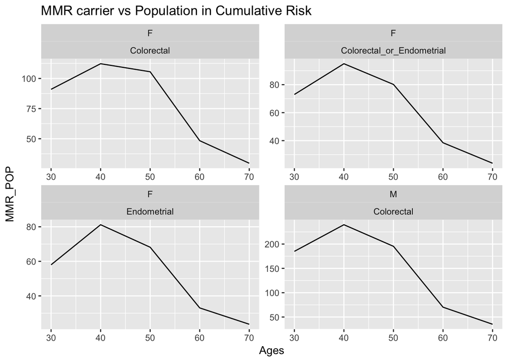

```r
st %>% ggplot() +
       facet_wrap(Gender ~ Type, scales = "free") +
       geom_line(aes(x = Ages, y = MMR_POP)) +
       ggtitle("MMR carrier vs Population in Cumulative Risk")
```

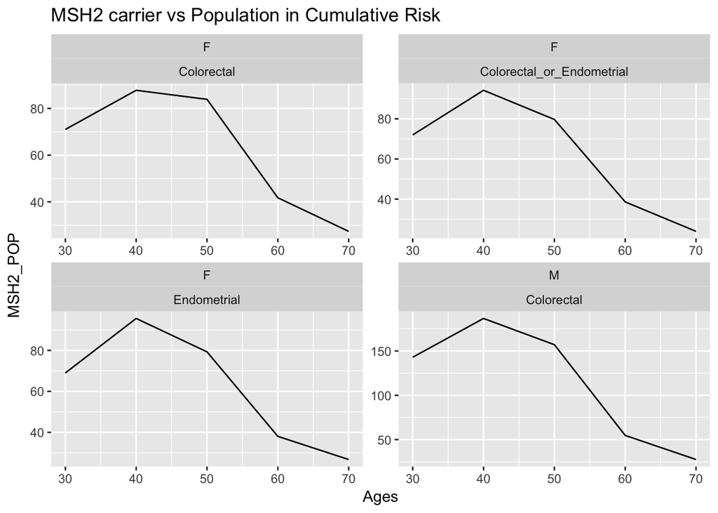

```r
st %>% ggplot() +
       facet_wrap(Gender ~ Type, scales = "free") +
       geom_line(aes(x = Ages, y = MSH2_POP)) +
       ggtitle("MSH2 carrier vs Population in Cumulative Risk")
```

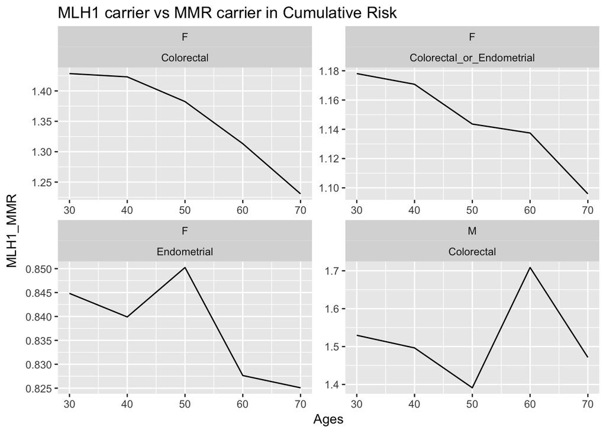

```r
st %>% ggplot() +
       facet_wrap(Gender ~ Type, scales = "free") +
       geom_line(aes(x = Ages, y = MLH1_MMR)) +
       ggtitle("MLH1 carrier vs MMR carrier in Cumulative Risk")
```

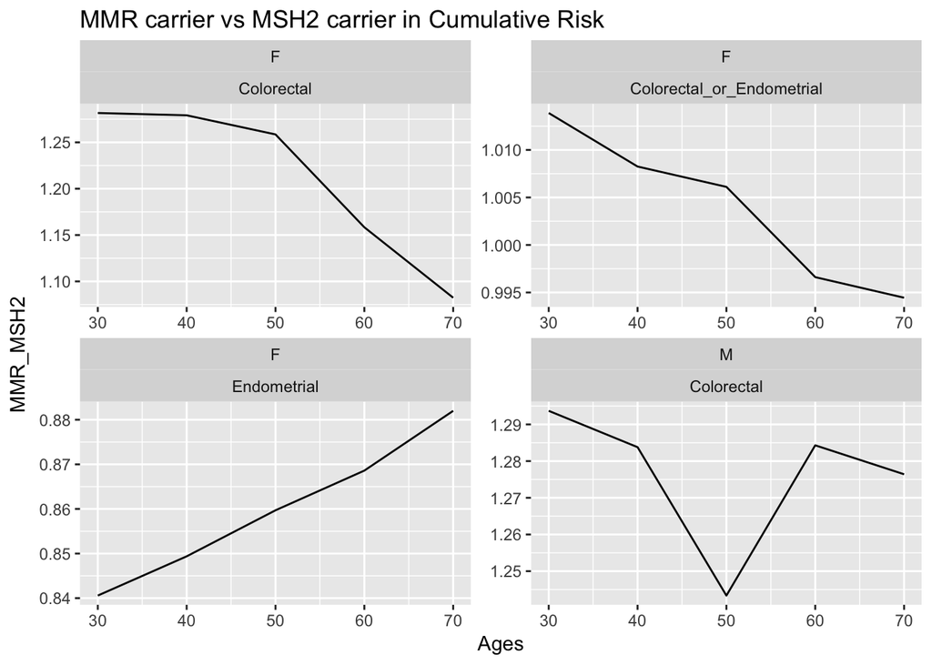

```r
st %>% ggplot() +
       facet_wrap(Gender ~ Type, scales = "free") +
       geom_line(aes(x = Ages, y = MMR_MSH2)) +
       ggtitle("MMR carrier vs MSH2 carrier in Cumulative Risk")
```

From the graph you can see the ratios are not very constant in `expose vs non-expose`. But it might be a good constant between different exposes.

## Test

Here we do statistical test for the constant ratio hypothesis. We have two ways for doing this. One is fitting the model $Y = \beta X$ and do goodness-of-fit test, and the other is to test if $\log Y_{i+1} - \log Y_i$ is equal to $\log X_{i+1} -\log X_i$ in pairs. Here’s we use the latter one.

```r
ratio.test <- function(X, Y){
    X.ratio = c()
    Y.ratio = c()
    n = length(X)
    for(i in 1:(n-1)) {
        X.ratio = c(X.ratio, log(X[i+1] / X[i]))
        Y.ratio = c(Y.ratio, log(Y[i+1] / Y[i]))
    }
    t.test(X.ratio, Y.ratio, paired = T)
}

### Peto data for Male
X = filter(Peto_NEJM, Gender=="M", Expose == "N") %>% arrange(Ages)
X = X$CR

Y = filter(Peto_NEJM, Gender=="M", Expose == "S") %>% arrange(Ages)
Y = Y$CR

##### Smoke vs Non smoke for Male
ratio.test(X, Y)
```

```
##
##  Paired t-test
##
## data:  X.ratio and Y.ratio
## t = 0.08105, df = 3, p-value = 0.9405
## alternative hypothesis: true difference in means is not equal to 0
## 95 percent confidence interval:
##  -0.5036075  0.5299294
## sample estimates:
## mean of the differences
##              0.01316093
```

```r
### Peto data for Female
X = filter(Peto_NEJM, Gender=="F", Expose == "N") %>% arrange(Ages)
X = X$CR

Y = filter(Peto_NEJM, Gender=="F", Expose == "S") %>% arrange(Ages)
Y = Y$CR

##### Smoke vs Non smoke for female
ratio.test(X, Y)
```

```
##
##  Paired t-test
##
## data:  X.ratio and Y.ratio
## t = -0.85206, df = 3, p-value = 0.4568
## alternative hypothesis: true difference in means is not equal to 0
## 95 percent confidence interval:
##  -0.8593262  0.4963577
## sample estimates:
## mean of the differences
##              -0.1814843
```

```r
### Stoffel data for Male: P value table
Stoffel.M = filter(Stoffel, Gender=="M")
Exposes = unique(Stoffel.M$Expose)
n = length(Exposes)
p_table = matrix(0, n, n)
rownames(p_table) = Exposes
colnames(p_table) = Exposes

for(u in Exposes) {
    for(v in Exposes) {
        X = Stoffel.M %>% filter(Expose == u)
        X = X$CR
        Y = Stoffel.M %>% filter(Expose == v)
        Y = Y$CR
        p_table[u, v] = ratio.test(X, Y)$p.value
    }
}

##### Male Colorectal
print(p_table)
```

```
##            POP       MMR      MLH1      MSH2
## POP        NaN 0.2355466 0.1958348 0.2502299
## MMR  0.2355466       NaN 0.9067961 0.8168306
## MLH1 0.1958348 0.9067961       NaN 0.8907282
## MSH2 0.2502299 0.8168306 0.8907282       NaN
```

```r
### Stoffel data for Female Colorectal: P value table
Stoffel.F = filter(Stoffel, Gender=="F", Type=="Colorectal")
Exposes = unique(Stoffel.F$Expose)
n = length(Exposes)
p_table = matrix(0, n, n)
rownames(p_table) = Exposes
colnames(p_table) = Exposes

for(u in Exposes) {
    for(v in Exposes) {
        X = Stoffel.F %>% filter(Expose == u)
        X = X$CR
        Y = Stoffel.F %>% filter(Expose == v)
        Y = Y$CR
        p_table[u, v] = ratio.test(X, Y)$p.value
    }
}

##### Female Colorectal
print(p_table)
```

```
##            POP        MMR       MLH1      MSH2
## POP        NaN 0.29272871 0.26459071 0.3213096
## MMR  0.2927287        NaN 0.06883345 0.1201186
## MLH1 0.2645907 0.06883345        NaN 0.0902219
## MSH2 0.3213096 0.12011856 0.09022190       NaN
```

```r
### Stoffel data for Female Endometrial: P value table
Stoffel.F = filter(Stoffel, Gender=="F", Type=="Endometrial")
Exposes = unique(Stoffel.F$Expose)
n = length(Exposes)
p_table = matrix(0, n, n)
rownames(p_table) = Exposes
colnames(p_table) = Exposes

for(u in Exposes) {
    for(v in Exposes) {
        X = Stoffel.F %>% filter(Expose == u)
        X = X$CR
        Y = Stoffel.F %>% filter(Expose == v)
        Y = Y$CR
        p_table[u, v] = ratio.test(X, Y)$p.value
    }
}

##### Female Endometrial
print(p_table)
```

```
##            POP         MMR      MLH1        MSH2
## POP        NaN 0.381287171 0.3786144 0.360098467
## MMR  0.3812872         NaN 0.5162474 0.001958858
## MLH1 0.3786144 0.516247420       NaN 0.528693612
## MSH2 0.3600985 0.001958858 0.5286936         NaN
```

```r
### Stoffel data for Female Colorectal_or_Endometria: P value table
Stoffel.F = filter(Stoffel, Gender=="F", Type=="Colorectal_or_Endometrial")
Exposes = unique(Stoffel.F$Expose)
n = length(Exposes)
p_table = matrix(0, n, n)
rownames(p_table) = Exposes
colnames(p_table) = Exposes

for(u in Exposes) {
    for(v in Exposes) {
        X = Stoffel.F %>% filter(Expose == u)
        X = X$CR
        Y = Stoffel.F %>% filter(Expose == v)
        Y = Y$CR
        p_table[u, v] = ratio.test(X, Y)$p.value
    }
}

##### Female Colorectal_or_Endometria
print(p_table)
```

```
##            POP        MMR       MLH1       MSH2
## POP        NaN 0.28345358 0.26225272 0.28925455
## MMR  0.2834536        NaN 0.09843460 0.06940221
## MLH1 0.2622527 0.09843460        NaN 0.03497202
## MSH2 0.2892545 0.06940221 0.03497202        NaN
```

You can see from here ratio for Male is quite constant in Peto data and in Stoffel data among different exposes (except population). But for female the ratio is quite not constant.